# Customer_Segmentation_SivasankariGG_Final

**1. Import All Libraries**

```python
# Import All Libraries
import pandas as pd
import numpy as np

import matplotlib.pylab as plt
%matplotlib inline

import seaborn as sns
from sklearn.model_selection  import train_test_split
from sklearn.cluster import KMeans

from scipy.stats import zscore
```

**2. Read CSV file into dataframe variable**

```python
#Read CSV file into dataframe variable
costumer_df = pd.read_csv("/content/sample_data/Customer_Data.csv")
credit_costumer = costumer_df.drop(columns=['Sl_No','Customer Key'],axis=1)
credit_costumer

# We are removing Sl_No and Customer Key because there seems to be little to no correlation between whether a particular
# Sl_No and Customer Key gives more impact on the upselling of current customers or attracting new customers.
```

|  | Avg_Credit_Limit | Total_Credit_Cards | Total_visits_bank | Total_visits_online | Total_calls_made |
| --- | --- | --- | --- | --- | --- |
| 0 | 100000 | 2 | 1 | 1 | 0 |
| 1 | 50000 | 3 | 0 | 10 | 9 |
| 2 | 50000 | 7 | 1 | 3 | 4 |
| 3 | 30000 | 5 | 1 | 1 | 4 |
| 4 | 100000 | 6 | 0 | 12 | 3 |
| ... | ... | ... | ... | ... | ... |
| 655 | 99000 | 10 | 1 | 10 | 0 |
| 656 | 84000 | 10 | 1 | 13 | 2 |
| 657 | 145000 | 8 | 1 | 9 | 1 |
| 658 | 172000 | 10 | 1 | 15 | 0 |
| 659 | 167000 | 9 | 0 | 12 | 2 |

660 rows × 5 columns

```python
#get the row and column size in the dataframe and get the top 5 rows
print(credit_costumer.shape)
print(credit_costumer.head())
```

```
(660, 5)
   Avg_Credit_Limit  Total_Credit_Cards  ...  Total_visits_online  Total_calls_made
0            100000                   2  ...                    1                 0
1             50000                   3  ...                   10                 9
2             50000                   7  ...                    3                 4
3             30000                   5  ...                    1                 4
4            100000                   6  ...                   12                 3

[5 rows x 5 columns]
```

**3. Find any missing values in dataframe**

```python
# Get the total number of missing value sin all the columns
credit_costumer.isna().sum()
```

```
Avg_Credit_Limit       0
Total_Credit_Cards     0
Total_visits_bank      0
Total_visits_online    0
Total_calls_made       0
dtype: int64
```

**4. Find Correaltion between each variable**

```python
# Getting to know the correlation amongst the attributes
cor = credit_costumer.corr()
cor
```

|  | Avg_Credit_Limit | Total_Credit_Cards | Total_visits_bank | Total_visits_online | Total_calls_made |
| --- | --- | --- | --- | --- | --- |
| Avg_Credit_Limit | 1.000000 | 0.608860 | -0.100312 | 0.551385 | -0.414352 |
| Total_Credit_Cards | 0.608860 | 1.000000 | 0.315796 | 0.167758 | -0.651251 |
| Total_visits_bank | -0.100312 | 0.315796 | 1.000000 | -0.551861 | -0.506016 |
| Total_visits_online | 0.551385 | 0.167758 | -0.551861 | 1.000000 | 0.127299 |
| Total_calls_made | -0.414352 | -0.651251 | -0.506016 | 0.127299 | 1.000000 |

**5. Describe Characteristics of each variable**

```python
# Finding the distribution of data right from count, mean, std, min and max values for all the attributes using describe.
credit_costumer.describe()
```

|  | Avg_Credit_Limit | Total_Credit_Cards | Total_visits_bank | Total_visits_online | Total_calls_made |
| --- | --- | --- | --- | --- | --- |
| count | 660.000000 | 660.000000 | 660.000000 | 660.000000 | 660.000000 |
| mean | 34574.242424 | 4.706061 | 2.403030 | 2.606061 | 3.583333 |
| std | 37625.487804 | 2.167835 | 1.631813 | 2.935724 | 2.865317 |
| min | 3000.000000 | 1.000000 | 0.000000 | 0.000000 | 0.000000 |
| 25% | 10000.000000 | 3.000000 | 1.000000 | 1.000000 | 1.000000 |
| 50% | 18000.000000 | 5.000000 | 2.000000 | 2.000000 | 3.000000 |
| 75% | 48000.000000 | 6.000000 | 4.000000 | 4.000000 | 5.000000 |
| max | 200000.000000 | 10.000000 | 5.000000 | 15.000000 | 10.000000 |

**6.Info about each variable in DF**

```python
credit_costumer.info()
```

```
<class 'pandas.core.frame.DataFrame'>
RangeIndex: 660 entries, 0 to 659
Data columns (total 5 columns):
 #   Column               Non-Null Count  Dtype
---  ------               --------------  -----
 0   Avg_Credit_Limit     660 non-null    int64
 1   Total_Credit_Cards   660 non-null    int64
 2   Total_visits_bank    660 non-null    int64
 3   Total_visits_online  660 non-null    int64
 4   Total_calls_made     660 non-null    int64
dtypes: int64(5)
memory usage: 25.9 KB
```

**7. Find count of any missing values**

```python
credit_costumer.isnull().count()
```

```
Avg_Credit_Limit       660
Total_Credit_Cards     660
Total_visits_bank      660
Total_visits_online    660
Total_calls_made       660
dtype: int64
```

**8. Print out names of all the columns in dataframe**

```python
credit_costumer.columns
```

```
Index(['Avg_Credit_Limit', 'Total_Credit_Cards', 'Total_visits_bank',
       'Total_visits_online', 'Total_calls_made'],
      dtype='object')
```

**9. Print all stats/metrics of each columns**

```python
credit_costumer.describe().transpose()
```

|  | count | mean | std | min | 25% | 50% | 75% | max |
| --- | --- | --- | --- | --- | --- | --- | --- | --- |
| Avg_Credit_Limit | 660.0 | 34574.242424 | 37625.487804 | 3000.0 | 10000.0 | 18000.0 | 48000.0 | 200000.0 |
| Total_Credit_Cards | 660.0 | 4.706061 | 2.167835 | 1.0 | 3.0 | 5.0 | 6.0 | 10.0 |
| Total_visits_bank | 660.0 | 2.403030 | 1.631813 | 0.0 | 1.0 | 2.0 | 4.0 | 5.0 |
| Total_visits_online | 660.0 | 2.606061 | 2.935724 | 0.0 | 1.0 | 2.0 | 4.0 | 15.0 |
| Total_calls_made | 660.0 | 3.583333 | 2.865317 | 0.0 | 1.0 | 3.0 | 5.0 | 10.0 |

**10. Print Skew of each variable**

```python
credit_costumer.skew().sort_values(ascending=False)
```

```
Total_visits_online    2.225607
Avg_Credit_Limit       2.202396
Total_calls_made       0.658905
Total_Credit_Cards     0.144879
Total_visits_bank      0.141896
dtype: float64
```

**11. Print unbiased Kurtosis**

```python
credit_costumer.kurt().sort_values(ascending=False)
```

```
Total_visits_online    5.739572
Avg_Credit_Limit       5.133842
Total_Credit_Cards    -0.369770
Total_calls_made      -0.518264
Total_visits_bank     -1.104274
dtype: float64
```

**12. Print all correlation which have a considerable significant impact on each other**

```python
#Print all correlation which have a considerable significant impact on each other
df = credit_costumer.corr()
df.columns
df[((df > 0.3) & (df < 1))| (df < -0.3)].dropna(how='all')
```

|  | Avg_Credit_Limit | Total_Credit_Cards | Total_visits_bank | Total_visits_online | Total_calls_made |
| --- | --- | --- | --- | --- | --- |
| Avg_Credit_Limit | NaN | 0.608860 | NaN | 0.551385 | -0.414352 |
| Total_Credit_Cards | 0.608860 | NaN | 0.315796 | NaN | -0.651251 |
| Total_visits_bank | NaN | 0.315796 | NaN | -0.551861 | -0.506016 |
| Total_visits_online | 0.551385 | NaN | -0.551861 | NaN | NaN |
| Total_calls_made | -0.414352 | -0.651251 | -0.506016 | NaN | NaN |

**Univariate Analysis**

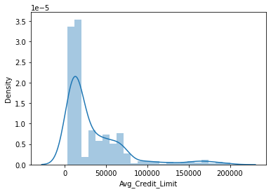

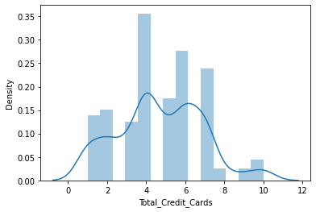

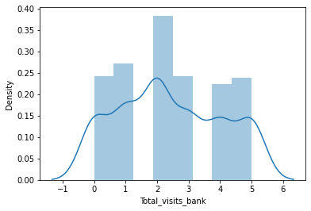

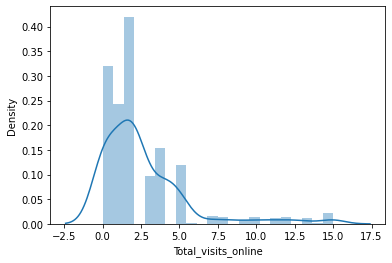

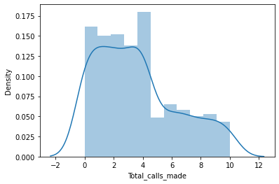

```python
# get the distplot for all the attributes
for i in ['Avg_Credit_Limit', 'Total_Credit_Cards', 'Total_visits_bank',
       'Total_visits_online', 'Total_calls_made']:
       sns.distplot(credit_costumer[i])
       plt.show()
```

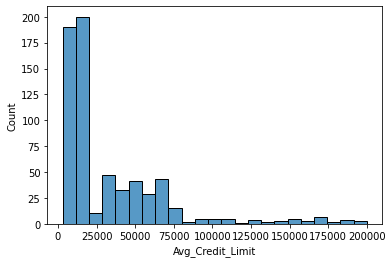

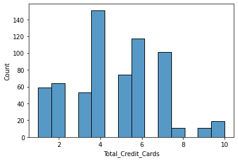

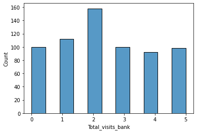

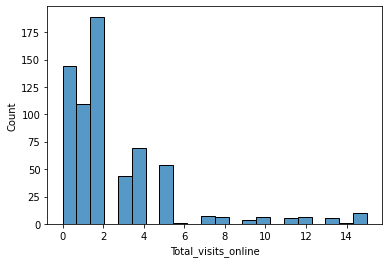

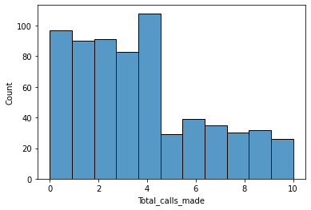

```python
# Get the Hist plot for all the attributes
for i in ['Avg_Credit_Limit', 'Total_Credit_Cards', 'Total_visits_bank',
       'Total_visits_online', 'Total_calls_made']:
       sns.histplot(credit_costumer[i])
       plt.show()
```

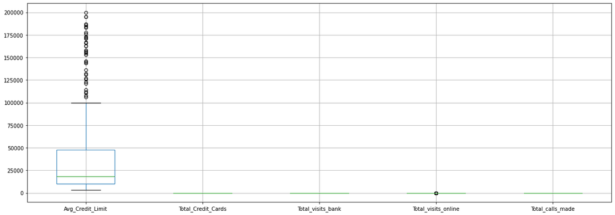

```python
# Get the box plot for all the attributes where avg_credit limit is in thousand where rest of the columns are around 10 so here those values are not displayed.
credit_costumer.boxplot(figsize=(20,7))
```

**Bivariate Analysis**

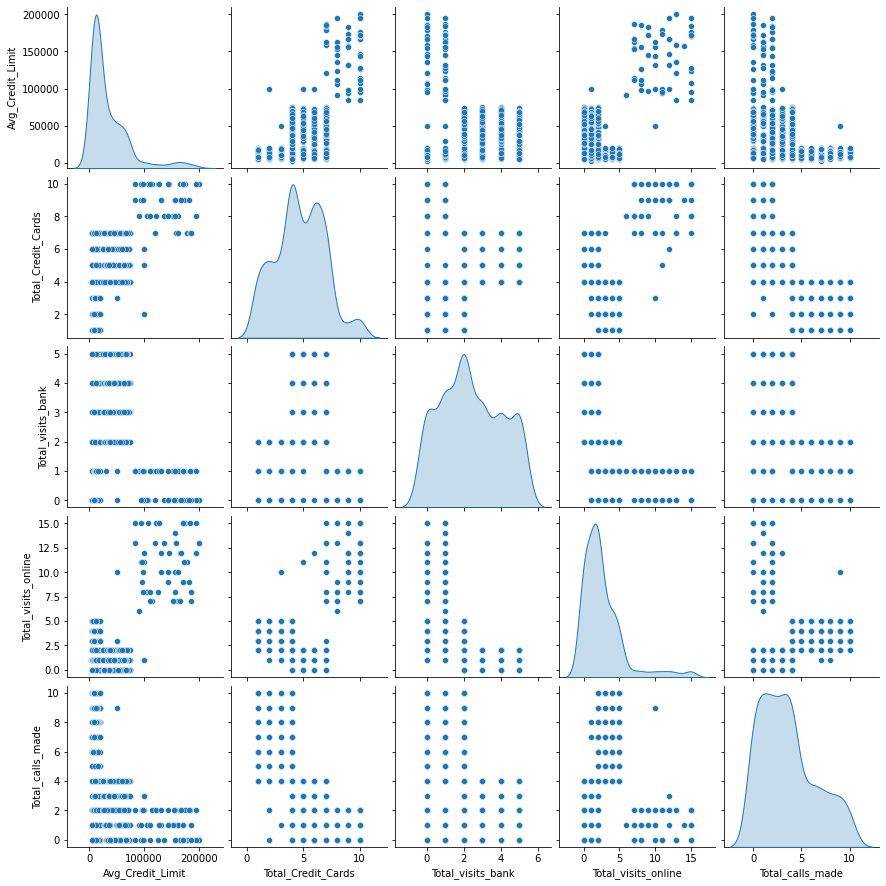

```python
# Getting the pairplot amongst the variables where diagonal graphs shows that the most of the attributes are having three to four spikes. which is ideal to have  to 4 groups
sns.pairplot(credit_costumer,diag_kind='kde')
```

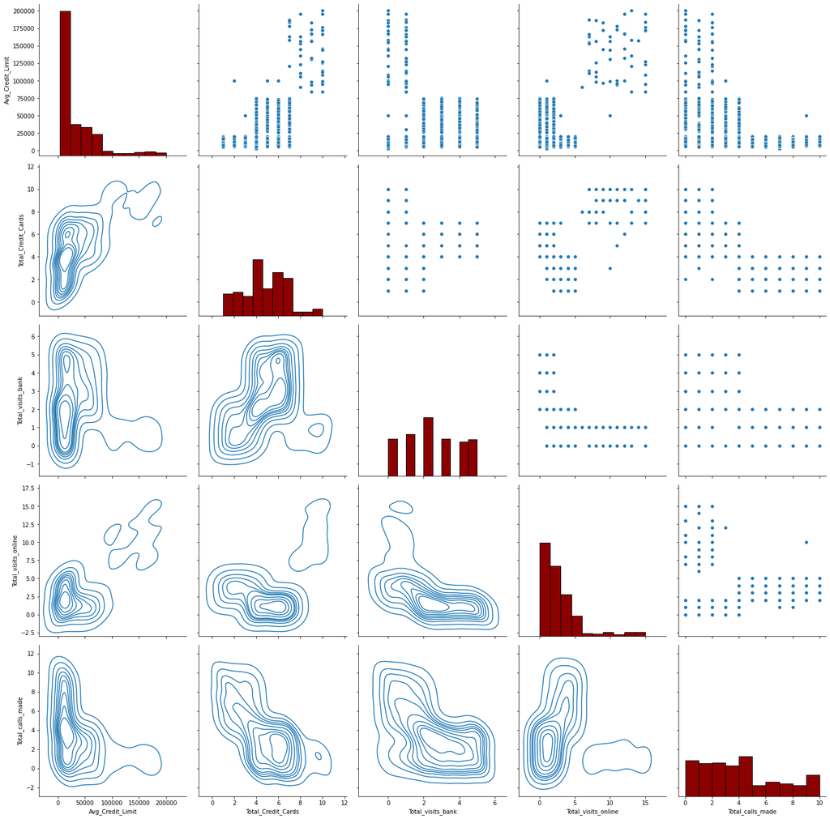

```python
# get the pairplot using seaborns library and diagonal graph with lower part of the graph with kernel density estimation and upper portion of the graph with scatter plot.
grid = sns.PairGrid(data= credit_costumer,
                    vars = ['Avg_Credit_Limit', 'Total_Credit_Cards', 'Total_visits_bank',
       'Total_visits_online', 'Total_calls_made'], size = 4)
grid = grid.map_upper(sns.scatterplot)
grid = grid.map_diag(plt.hist, bins = 10, color = 'darkred', edgecolor = 'k')
grid = grid.map_lower(sns.kdeplot)
```

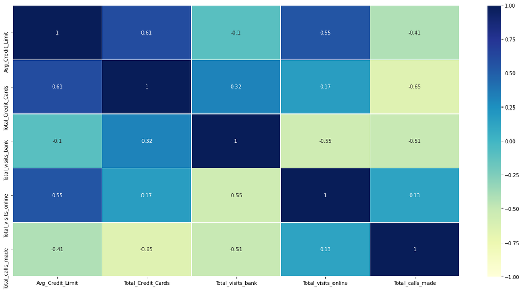

```python
# get the heat map to find the correlation amongst the attributes
plt.figure(figsize=(20,10))
sns.heatmap(credit_costumer.corr(),annot=True,linewidths=.5,center=0,cbar=True,cmap="YlGnBu",vmin=-1,vmax=+1)
plt.show()
```

```python
# Print the top 5 rows
credit_costumer.head()
```

|  | Avg_Credit_Limit | Total_Credit_Cards | Total_visits_bank | Total_visits_online | Total_calls_made |
| --- | --- | --- | --- | --- | --- |
| 0 | 100000 | 2 | 1 | 1 | 0 |
| 1 | 50000 | 3 | 0 | 10 | 9 |
| 2 | 50000 | 7 | 1 | 3 | 4 |
| 3 | 30000 | 5 | 1 | 1 | 4 |
| 4 | 100000 | 6 | 0 | 12 | 3 |

```python
credit_costumer['Avg_Credit_Limit'] = np.log(credit_costumer['Avg_Credit_Limit'])
credit_costumer.head()
```

|  | Avg_Credit_Limit | Total_Credit_Cards | Total_visits_bank | Total_visits_online | Total_calls_made |
| --- | --- | --- | --- | --- | --- |
| 0 | 11.512925 | 2 | 1 | 1 | 0 |
| 1 | 10.819778 | 3 | 0 | 10 | 9 |
| 2 | 10.819778 | 7 | 1 | 3 | 4 |
| 3 | 10.308953 | 5 | 1 | 1 | 4 |
| 4 | 11.512925 | 6 | 0 | 12 | 3 |

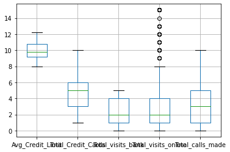

```python
credit_costumer.boxplot()
```

**K-Means Clustering and Analysing Clusters using Box Plot**

In the below block of code we are finding the z score of the credit_customer df to find out the relationship of each column's median to each other column's median.

```python
# import zscore
from scipy.stats import zscore
#In the below block of code we are finding the z score of the credit_customer df to find out the relationship of each column's median to each other column's median.
credit_costumer.dtypes
numeric_cols = credit_costumer.select_dtypes(include=[np.int64, np.float64]).columns
numeric_cols
credit_costumer[numeric_cols] = credit_costumer[numeric_cols].apply(zscore)
```

```python
credit_costumer.head()
```

|  | Avg_Credit_Limit | Total_Credit_Cards | Total_visits_bank | Total_visits_online | Total_calls_made |
| --- | --- | --- | --- | --- | --- |
| 0 | 1.630478 | -1.249225 | -0.860451 | -0.547490 | -1.251537 |
| 1 | 0.885387 | -0.787585 | -1.473731 | 2.520519 | 1.891859 |
| 2 | 0.885387 | 1.058973 | -0.860451 | 0.134290 | 0.145528 |
| 3 | 0.336281 | 0.135694 | -0.860451 | -0.547490 | 0.145528 |
| 4 | 1.630478 | 0.597334 | -1.473731 | 3.202298 | -0.203739 |

In the below block of code we are searching for the best cluster pattern to find out the types of groups of customers in the dataset.

```python
#In the below block of code we are searching for the best cluster pattern to find out the types of groups of customers in the dataset.
#where considered 15 clusters
cluster_range = range(1,15)
cluster_errors = []
for num_clusters in cluster_range:
    clusters = KMeans(num_clusters, n_init = 10)
    clusters.fit(credit_costumer)
    labels = clusters.labels_
    centroids = clusters.cluster_centers_
    cluster_errors.append(clusters.inertia_)

clusters_df = pd.DataFrame({"num_clusters": cluster_range, "cluster_errors": cluster_errors})
clusters_df[0:15]
```

|  | num_clusters | cluster_errors |
| --- | --- | --- |
| 0 | 1 | 3300.000000 |
| 1 | 2 | 1980.654971 |
| 2 | 3 | 1090.350994 |
| 3 | 4 | 860.748318 |
| 4 | 5 | 775.802835 |
| 5 | 6 | 698.255196 |
| 6 | 7 | 634.212081 |
| 7 | 8 | 605.152842 |
| 8 | 9 | 571.098191 |
| 9 | 10 | 543.234451 |
| 10 | 11 | 519.659626 |
| 11 | 12 | 495.300834 |
| 12 | 13 | 484.837577 |
| 13 | 14 | 465.430947 |

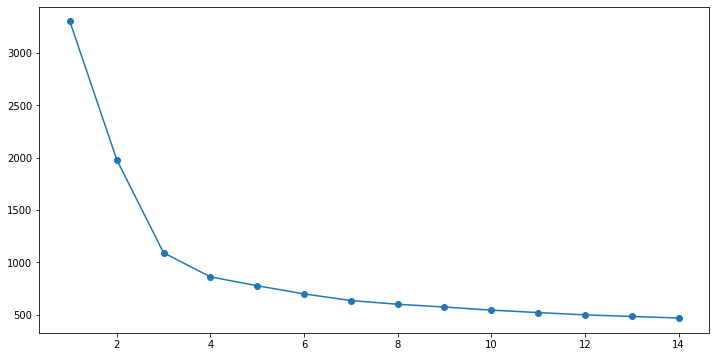

```python
# elbow method to find an optimal number of clusters it takes sharp turn at 3 and to some extent to 4 so decided to have three and four clusters
from matplotlib import cm

plt.figure(figsize=(12,6))
plt.plot( clusters_df.num_clusters, clusters_df.cluster_errors, marker = "o" )
```

**K-means clustering with cluster size as three**

```python
# group the custoers data using k-means clustering algorithm with cluster size as 3
credit_costumer_3 = credit_costumer.copy()
kmeans = KMeans(n_clusters=3, n_init =10, random_state=41)
kmeans.fit(credit_costumer_3)
```

```
KMeans(algorithm='auto', copy_x=True, init='k-means++', max_iter=300,
       n_clusters=3, n_init=10, n_jobs=None, precompute_distances='auto',
       random_state=41, tol=0.0001, verbose=0)
```

```python
# Each cluster size
# first group is cluttered with more data than the last group
labels = kmeans.labels_
counts = np.bincount(labels[labels>=0])
print(counts)
```

```
[385 225  50]
```

```python
# Compute centroids for each clusters
centroids = kmeans.cluster_centers_
centroid_df = pd.DataFrame(centroids, columns = list(credit_costumer_3))
centroid_df.transpose()
```

|  | 0 | 1 | 2 |
| --- | --- | --- | --- |
| Avg_Credit_Limit | 0.171814 | -0.730991 | 1.966490 |
| Total_Credit_Cards | 0.374308 | -1.054310 | 1.862226 |
| Total_visits_bank | 0.668767 | -0.898610 | -1.105763 |
| Total_visits_online | -0.554573 | 0.320643 | 2.827319 |
| Total_calls_made | -0.554819 | 1.143653 | -0.874330 |

```python
# The best value is 1 and the worst value is -1.
#Values near 0 indicate overlapping clusters.
#Negative values generally indicate that a sample has been assigned to the wrong cluster, as a different cluster is more similar.
from sklearn.metrics import silhouette_samples, silhouette_score
predictions = kmeans.predict(credit_costumer_3)
predictions
#S1 =  {silhouette_score(credit_costumer_3, predictions)}
S1a = silhouette_score(credit_costumer_3, predictions)
print(S1a)
print(f'Silhouette Score(n=3: {S1a}')
credit_costumer_3["group"] = predictions
credit_costumer_3['group'] = credit_costumer_3['group'].astype('category')
credit_costumer_3.dtypes
```

```
0.4930010449995642
Silhouette Score(n=3: 0.4930010449995642
```

```
Avg_Credit_Limit        float64
Total_Credit_Cards      float64
Total_visits_bank       float64
Total_visits_online     float64
Total_calls_made        float64
group                  category
dtype: object
```

```
array([[<matplotlib.axes._subplots.AxesSubplot object at 0x7fae489000f0>,
      dtype=object)
```

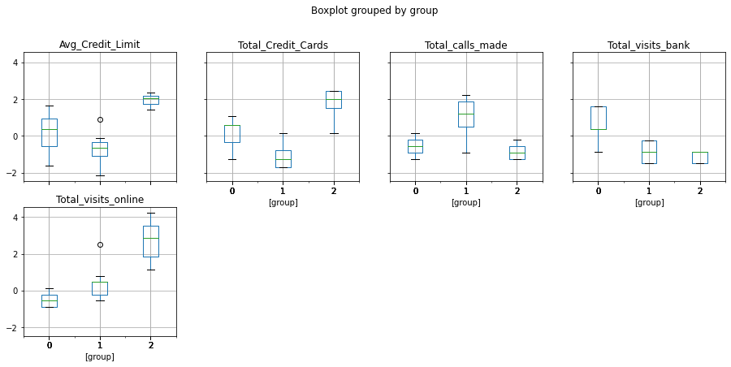

```python
credit_costumer_3["group"] = predictions
credit_costumer_3.boxplot(by = 'group',  layout=(3,4), figsize=(15, 10))
```

Group 2(Premium): They are the customers with the high credit limit, holding many number of credit cards. They do not attempt to call a bank and rarely visits the bank in person but they perfered to do transaction in online most of the time.

**K-means clustering with cluster size as Four**

```python
# group the custoers data using k-means clustering algorithm with cluster size as 4
credit_costumer_4 = credit_costumer.copy()
kmeans = KMeans(n_clusters=4, n_init =10, random_state=41)
kmeans.fit(credit_costumer_4)
```

```
KMeans(algorithm='auto', copy_x=True, init='k-means++', max_iter=300,
       n_clusters=4, n_init=10, n_jobs=None, precompute_distances='auto',
       random_state=41, tol=0.0001, verbose=0)
```

```python
# Each cluster size
labels = kmeans.labels_
counts = np.bincount(labels[labels>=0])
print(counts)
```

```
[223 219  50 168]
```

```python
# Compute centroids for each clusters
centroids = kmeans.cluster_centers_
centroid_df = pd.DataFrame(centroids, columns = list(credit_costumer_4))
centroid_df.transpose()
```

|  | 0 | 1 | 2 | 3 |
| --- | --- | --- | --- | --- |
| Avg_Credit_Limit | -0.726532 | 0.838906 | 1.966490 | -0.714454 |
| Total_Credit_Cards | -1.062913 | 0.388647 | 1.862226 | 0.350027 |
| Total_visits_bank | -0.904453 | 0.612542 | -1.105763 | 0.731157 |
| Total_visits_online | 0.325372 | -0.558386 | 2.827319 | -0.545461 |
| Total_calls_made | 1.152605 | -0.533867 | -0.874330 | -0.573795 |

```python
# The best value is 1 and the worst value is -1.
#Values near 0 indicate overlapping clusters.
#Negative values generally indicate that a sample has been assigned to the wrong cluster, as a different cluster is more similar.
from sklearn.metrics import silhouette_samples, silhouette_score
predictions = kmeans.predict(credit_costumer_4)
predictions
S2a = silhouette_score(credit_costumer_4, predictions)
print(f'Silhouette Score(n=4: {S2a}')
credit_costumer_4["group"] = predictions
credit_costumer_4['group'] = credit_costumer_4['group'].astype('category')
credit_costumer_4.dtypes
```

```
Silhouette Score(n=4: 0.3849070337583928
```

```
Avg_Credit_Limit        float64
Total_Credit_Cards      float64
Total_visits_bank       float64
Total_visits_online     float64
Total_calls_made        float64
group                  category
dtype: object
```

```
array([[<matplotlib.axes._subplots.AxesSubplot object at 0x7fae482e31d0>,
      dtype=object)
```

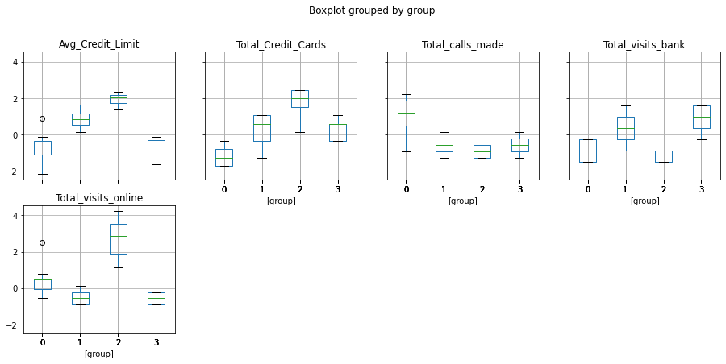

```python
credit_costumer_4["group"] = predictions
credit_costumer_4.boxplot(by = 'group',  layout=(3,4), figsize=(15, 10))
```

**Hierarchial Clustering for Average, Complete and Ward linkages (dendodiagrams and cophenetic coeff) with cluater size as 3**

```python
# Apply z score on all the columns for building hierarchical clustering
credit_costumer_z_hc = credit_costumer.apply(zscore)
credit_costumer_z_hc
```

|  | Avg_Credit_Limit | Total_Credit_Cards | Total_visits_bank | Total_visits_online | Total_calls_made |
| --- | --- | --- | --- | --- | --- |
| 0 | 1.630478 | -1.249225 | -0.860451 | -0.547490 | -1.251537 |
| 1 | 0.885387 | -0.787585 | -1.473731 | 2.520519 | 1.891859 |
| 2 | 0.885387 | 1.058973 | -0.860451 | 0.134290 | 0.145528 |
| 3 | 0.336281 | 0.135694 | -0.860451 | -0.547490 | 0.145528 |
| 4 | 1.630478 | 0.597334 | -1.473731 | 3.202298 | -0.203739 |
| ... | ... | ... | ... | ... | ... |
| 655 | 1.619674 | 2.443892 | -0.860451 | 2.520519 | -1.251537 |
| 656 | 1.443058 | 2.443892 | -0.860451 | 3.543188 | -0.553005 |
| 657 | 2.029885 | 1.520613 | -0.860451 | 2.179629 | -0.902271 |
| 658 | 2.213443 | 2.443892 | -0.860451 | 4.224968 | -1.251537 |
| 659 | 2.181731 | 1.982253 | -1.473731 | 3.202298 | -0.553005 |

660 rows × 5 columns

```python
#import AgglomerativeClustering for hierarchical clustering
#Hierarchical clustering using average Linkae and Distance between two points computed using Euclidean
from sklearn.cluster import AgglomerativeClustering
credit_costumer_z_hc_avg_3 = credit_costumer_z_hc.copy()
model_average = AgglomerativeClustering(n_clusters=3, affinity='euclidean',  linkage='average')
```

```python
# build hierarchical clustering model
model_average.fit(credit_costumer_z_hc_avg_3)
```

```
AgglomerativeClustering(affinity='euclidean', compute_full_tree='auto',
                        connectivity=None, distance_threshold=None,
                        linkage='average', memory=None, n_clusters=3)
```

```python
credit_costumer_z_hc_avg_3['labels'] = model_average.labels_
credit_costumer_z_hc_avg_3.head(5)
```

|  | Avg_Credit_Limit | Total_Credit_Cards | Total_visits_bank | Total_visits_online | Total_calls_made | labels |
| --- | --- | --- | --- | --- | --- | --- |
| 0 | 1.630478 | -1.249225 | -0.860451 | -0.547490 | -1.251537 | 2 |
| 1 | 0.885387 | -0.787585 | -1.473731 | 2.520519 | 1.891859 | 0 |
| 2 | 0.885387 | 1.058973 | -0.860451 | 0.134290 | 0.145528 | 2 |
| 3 | 0.336281 | 0.135694 | -0.860451 | -0.547490 | 0.145528 | 2 |
| 4 | 1.630478 | 0.597334 | -1.473731 | 3.202298 | -0.203739 | 1 |

```python
credit_costumer_clust = credit_costumer_z_hc_avg_3.groupby(['labels'])
```

```python
# get the mean value for all the groups and for all the columns/attributes
credit_costumer_clust.mean()
```

| labels | Avg_Credit_Limit | Total_Credit_Cards | Total_visits_bank | Total_visits_online | Total_calls_made |
| --- | --- | --- | --- | --- | --- |
| 0 | -0.721773 | -1.070864 | -0.902265 | 0.334175 | 1.169513 |
| 1 | 1.966490 | 1.862226 | -1.105763 | 2.827319 | -0.874330 |
| 2 | 0.155040 | 0.365330 | 0.650735 | -0.550986 | -0.547632 |

```python
# import cophenet, dendrogram, linkage
from scipy.cluster.hierarchy import cophenet, dendrogram, linkage
from scipy.spatial.distance import pdist
```

```python
## cophenet index is a measure of the correlation between the distance of points in feature space and distance on dendrogram
# closer it is to 1, the better is the clustering
z1 = linkage(credit_costumer_z_hc_avg_3, metric='euclidean', method='average')
c1, coph_dists = cophenet(z1 , pdist(credit_costumer_z_hc_avg_3))

c1
```

```
0.9067377076711735
```

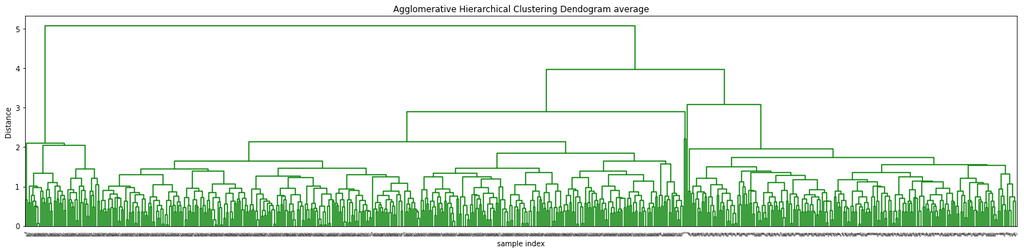

```python
## plot Agglomerative Hierarchical Clustering Dendogram average'
plt.figure(figsize=(20, 5))
plt.title('Agglomerative Hierarchical Clustering Dendogram average')
plt.xlabel('sample index')
plt.ylabel('Distance')
dendrogram(z1, leaf_rotation=45.,color_threshold = 40, leaf_font_size=4. )
plt.tight_layout()
```

```python
#Get the silhoutte score of the hierarchical clustering, it always used to be beween -1 to 1 for better clustering it would be 1 and - means bad clustering
#The best value is 1 and the worst value is -1. Values near 0 indicate overlapping clusters.
#Negative values generally indicate that a sample has been assigned to the wrong cluster, as a different cluster is more similar.
preds_h = model_average.fit_predict(credit_costumer_z_hc_avg_3)
S3 = silhouette_score(credit_costumer_z_hc_avg_3,preds_h)
S3
```

```
0.5629956907352197
```

```python
#import AgglomerativeClustering for hierarchical clustering
from sklearn.cluster import AgglomerativeClustering
credit_costumer_z_hc_cmplt_3 = credit_costumer_z_hc.copy()
model_average = AgglomerativeClustering(n_clusters=3, affinity='euclidean',  linkage='complete')
```

```python
# build hierarchical clustering model
model_average.fit(credit_costumer_z_hc_cmplt_3)
```

```
AgglomerativeClustering(affinity='euclidean', compute_full_tree='auto',
                        connectivity=None, distance_threshold=None,
                        linkage='complete', memory=None, n_clusters=3)
```

```python
credit_costumer_z_hc_cmplt_3['labels'] = model_average.labels_
credit_costumer_z_hc_cmplt_3.head(5)
```

|  | Avg_Credit_Limit | Total_Credit_Cards | Total_visits_bank | Total_visits_online | Total_calls_made | labels |
| --- | --- | --- | --- | --- | --- | --- |
| 0 | 1.630478 | -1.249225 | -0.860451 | -0.547490 | -1.251537 | 0 |
| 1 | 0.885387 | -0.787585 | -1.473731 | 2.520519 | 1.891859 | 2 |
| 2 | 0.885387 | 1.058973 | -0.860451 | 0.134290 | 0.145528 | 0 |
| 3 | 0.336281 | 0.135694 | -0.860451 | -0.547490 | 0.145528 | 0 |
| 4 | 1.630478 | 0.597334 | -1.473731 | 3.202298 | -0.203739 | 1 |

```python
credit_costumer_clust = credit_costumer_z_hc_cmplt_3.groupby(['labels'])
```

```python
# cophenet index is a measure of the correlation between the distance of points in feature space and distance on dendrogram
# closer it is to 1, the better is the clustering

z2 = linkage(credit_costumer_z_hc_cmplt_3, metric='euclidean', method='complete')
c2, coph_dists = cophenet(z2, pdist(credit_costumer_z_hc_cmplt_3))

c2
```

```
0.8859529904901793
```

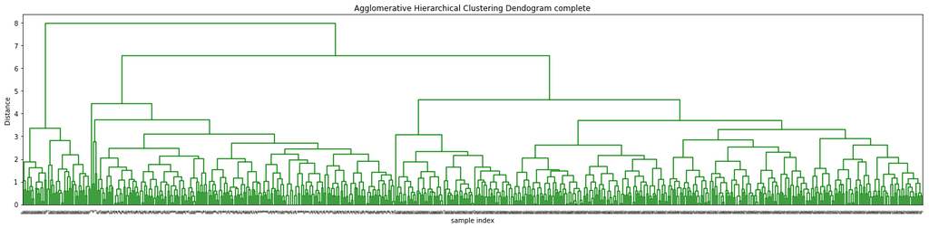

```python
# plot Agglomerative Hierarchical Clustering Dendogram complete'
plt.figure(figsize=(20, 5))
plt.title('Agglomerative Hierarchical Clustering Dendogram complete')
plt.xlabel('sample index')
plt.ylabel('Distance')
dendrogram(z2, leaf_rotation=45.,color_threshold = 600, leaf_font_size=4. )
plt.tight_layout()
```

```python
#Get the silhoutte score of the hierarchical clustering, it always used to be beween -1 to 1 for better clustering it would be 1 and - means bad clustering
#The best value is 1 and the worst value is -1. Values near 0 indicate overlapping clusters.
#Negative values generally indicate that a sample has been assigned to the wrong cluster, as a different cluster is more similar.
preds_h = model_average.fit_predict(credit_costumer_z_hc_cmplt_3)
S4 = silhouette_score(credit_costumer_z_hc_cmplt_3,preds_h)
S4
```

```
0.5649944340363303
```

```python
# cophenet index is a measure of the correlation between the distance of points in feature space and distance on dendrogram
# closer it is to 1, the better is the clustering
credit_costumer_z_hc_ward_3 = credit_costumer_z_hc.copy()

model_average = AgglomerativeClustering(n_clusters=3, affinity='euclidean',  linkage='ward')

# build hierarchical clustering model
model_average.fit(credit_costumer_z_hc_ward_3)

credit_costumer_z_hc_ward_3['labels'] = model_average.labels_
credit_costumer_z_hc_ward_3.head(5)
credit_costumer_clust = credit_costumer_z_hc_ward_3.groupby(['labels'])
z3 = linkage(credit_costumer_z_hc_ward_3, metric='euclidean', method='ward')
c3, coph_dists = cophenet(z3 , pdist(credit_costumer_z_hc_ward_3))

c3
```

```
0.7774027426226143
```

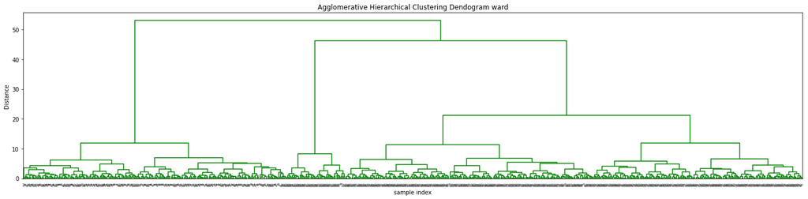

```python
## plot Agglomerative Hierarchical Clustering Dendogram ward
plt.figure(figsize=(20, 5))
plt.title('Agglomerative Hierarchical Clustering Dendogram ward')
plt.xlabel('sample index')
plt.ylabel('Distance')
dendrogram(z3, leaf_rotation=45.,color_threshold = 600, leaf_font_size=4. )
plt.tight_layout()
```

```python
#Get the silhoutte score of the hierarchical clustering, it always used to be beween -1 to 1 for better clustering it would be 1 and - means bad clustering
#The best value is 1 and the worst value is -1. Values near 0 indicate overlapping clusters.
#Negative values generally indicate that a sample has been assigned to the wrong cluster, as a different cluster is more similar.
preds_h = model_average.fit_predict(credit_costumer_z_hc_ward_3)
S5 = silhouette_score(credit_costumer_z_hc_ward_3,preds_h)
S5
```

```
0.5175612857605055
```

**Hierarchial Clustering for Average, Complete and Ward linkages (dendodiagrams and cophenetic coeff) with cluater size as 4**

```python
#import AgglomerativeClustering for hierarchical clustering
from sklearn.cluster import AgglomerativeClustering
credit_costumer_z_hc_avg_4 = credit_costumer_z_hc.copy()
model_average = AgglomerativeClustering(n_clusters=4, affinity='euclidean',  linkage='average')
credit_costumer_z_hc_avg_4
```

|  | Avg_Credit_Limit | Total_Credit_Cards | Total_visits_bank | Total_visits_online | Total_calls_made |
| --- | --- | --- | --- | --- | --- |
| 0 | 1.630478 | -1.249225 | -0.860451 | -0.547490 | -1.251537 |
| 1 | 0.885387 | -0.787585 | -1.473731 | 2.520519 | 1.891859 |
| 2 | 0.885387 | 1.058973 | -0.860451 | 0.134290 | 0.145528 |
| 3 | 0.336281 | 0.135694 | -0.860451 | -0.547490 | 0.145528 |
| 4 | 1.630478 | 0.597334 | -1.473731 | 3.202298 | -0.203739 |
| ... | ... | ... | ... | ... | ... |
| 655 | 1.619674 | 2.443892 | -0.860451 | 2.520519 | -1.251537 |
| 656 | 1.443058 | 2.443892 | -0.860451 | 3.543188 | -0.553005 |
| 657 | 2.029885 | 1.520613 | -0.860451 | 2.179629 | -0.902271 |
| 658 | 2.213443 | 2.443892 | -0.860451 | 4.224968 | -1.251537 |
| 659 | 2.181731 | 1.982253 | -1.473731 | 3.202298 | -0.553005 |

660 rows × 5 columns

```python
# build hierarchical clustering model
model_average.fit(credit_costumer_z_hc_avg_4)
```

```
AgglomerativeClustering(affinity='euclidean', compute_full_tree='auto',
                        connectivity=None, distance_threshold=None,
                        linkage='average', memory=None, n_clusters=4)
```

```python
credit_costumer_z_hc_avg_4['labels'] = model_average.labels_
credit_costumer_z_hc_avg_4.head(5)
```

|  | Avg_Credit_Limit | Total_Credit_Cards | Total_visits_bank | Total_visits_online | Total_calls_made | labels |
| --- | --- | --- | --- | --- | --- | --- |
| 0 | 1.630478 | -1.249225 | -0.860451 | -0.547490 | -1.251537 | 0 |
| 1 | 0.885387 | -0.787585 | -1.473731 | 2.520519 | 1.891859 | 3 |
| 2 | 0.885387 | 1.058973 | -0.860451 | 0.134290 | 0.145528 | 0 |
| 3 | 0.336281 | 0.135694 | -0.860451 | -0.547490 | 0.145528 | 0 |
| 4 | 1.630478 | 0.597334 | -1.473731 | 3.202298 | -0.203739 | 1 |

```python
credit_costumer_clust = credit_costumer_z_hc_avg_4.groupby(['labels'])
credit_costumer_z_hc_avg_4 = credit_costumer_z_hc_avg_4.drop(['labels'],axis=1)
credit_costumer_z_hc_avg_4
```

|  | Avg_Credit_Limit | Total_Credit_Cards | Total_visits_bank | Total_visits_online | Total_calls_made |
| --- | --- | --- | --- | --- | --- |
| 0 | 1.630478 | -1.249225 | -0.860451 | -0.547490 | -1.251537 |
| 1 | 0.885387 | -0.787585 | -1.473731 | 2.520519 | 1.891859 |
| 2 | 0.885387 | 1.058973 | -0.860451 | 0.134290 | 0.145528 |
| 3 | 0.336281 | 0.135694 | -0.860451 | -0.547490 | 0.145528 |
| 4 | 1.630478 | 0.597334 | -1.473731 | 3.202298 | -0.203739 |
| ... | ... | ... | ... | ... | ... |
| 655 | 1.619674 | 2.443892 | -0.860451 | 2.520519 | -1.251537 |
| 656 | 1.443058 | 2.443892 | -0.860451 | 3.543188 | -0.553005 |
| 657 | 2.029885 | 1.520613 | -0.860451 | 2.179629 | -0.902271 |
| 658 | 2.213443 | 2.443892 | -0.860451 | 4.224968 | -1.251537 |
| 659 | 2.181731 | 1.982253 | -1.473731 | 3.202298 | -0.553005 |

660 rows × 5 columns

```python
from scipy.cluster.hierarchy import cophenet, dendrogram, linkage
from scipy.spatial.distance import pdist
```

```python
## cophenet index is a measure of the correlation between the distance of points in feature space and distance on dendrogram
# closer it is to 1, the better is the clustering
z4 = linkage(credit_costumer_z_hc_avg_4, metric='euclidean', method='average')
c4, coph_dists = cophenet(z4 , pdist(credit_costumer_z_hc_avg_4))

c4
```

```
0.8688916237932554
```

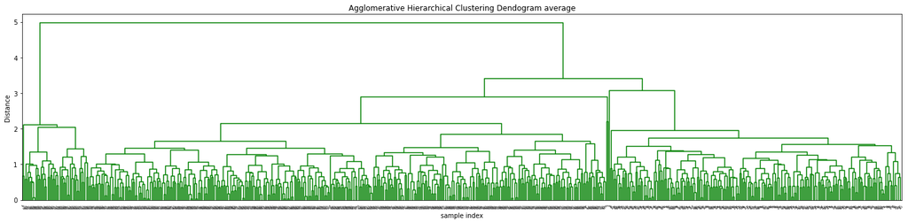

```python
## plot Agglomerative Hierarchical Clustering Dendogram average'
plt.figure(figsize=(20, 5))
plt.title('Agglomerative Hierarchical Clustering Dendogram average')
plt.xlabel('sample index')
plt.ylabel('Distance')
dendrogram(z4, leaf_rotation=45.,color_threshold = 40, leaf_font_size=4. )
plt.tight_layout()
```

```python
#Get the silhoutte score of the hierarchical clustering, it always used to be beween -1 to 1 for better clustering it would be 1 and - means bad clustering
#The best value is 1 and the worst value is -1. Values near 0 indicate overlapping clusters.
#Negative values generally indicate that a sample has been assigned to the wrong cluster, as a different cluster is more similar.
preds_h = model_average.fit_predict(credit_costumer_z_hc_avg_4)
S6 = silhouette_score(credit_costumer_z_hc_avg_4,preds_h)
S6
```

```
0.46047225708925726
```

```python
# cophenet index is a measure of the correlation between the distance of points in feature space and distance on dendrogram
# closer it is to 1, the better is the clustering
credit_costumer_z_hc_cmplt_4 = credit_costumer_z_hc.copy()

model_average = AgglomerativeClustering(n_clusters=4, affinity='euclidean',  linkage='complete')

# build hierarchical clustering model
model_average.fit(credit_costumer_z_hc_cmplt_4)

credit_costumer_z_hc_cmplt_4['labels'] = model_average.labels_
credit_costumer_z_hc_cmplt_4.head(5)
credit_costumer_clust = credit_costumer_z_hc_cmplt_4.groupby(['labels'])

z5 = linkage(credit_costumer_z_hc_cmplt_4, metric='euclidean', method='complete')
c5, coph_dists = cophenet(z5, pdist(credit_costumer_z_hc_cmplt_4))

c5
```

```
0.8980857959572328
```

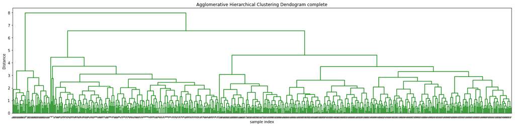

```python
# plot Agglomerative Hierarchical Clustering Dendogram complete'
plt.figure(figsize=(20, 5))
plt.title('Agglomerative Hierarchical Clustering Dendogram complete')
plt.xlabel('sample index')
plt.ylabel('Distance')
dendrogram(z2, leaf_rotation=45.,color_threshold = 600, leaf_font_size=4. )
plt.tight_layout()
```

```python
#Get the silhoutte score of the hierarchical clustering, it always used to be beween -1 to 1 for better clustering it would be 1 and - means bad clustering
#The best value is 1 and the worst value is -1. Values near 0 indicate overlapping clusters.
#Negative values generally indicate that a sample has been assigned to the wrong cluster, as a different cluster is more similar.
preds_h = model_average.fit_predict(credit_costumer_z_hc_cmplt_4)
S7 = silhouette_score(credit_costumer_z_hc_cmplt_4,preds_h)
S7
```

```
0.39977163273843624
```

```python
# cophenet index is a measure of the correlation between the distance of points in feature space and distance on dendrogram
# closer it is to 1, the better is the clustering
credit_costumer_z_hc_ward_4 = credit_costumer_z_hc.copy()

model_average = AgglomerativeClustering(n_clusters=4, affinity='euclidean',  linkage='ward')

# build hierarchical clustering model
model_average.fit(credit_costumer_z_hc_ward_4)

credit_costumer_z_hc_ward_4['labels'] = model_average.labels_
credit_costumer_z_hc_ward_4.head(5)
credit_costumer_clust = credit_costumer_z_hc_ward_4.groupby(['labels'])
z6 = linkage(credit_costumer_z_hc_ward_4, metric='euclidean', method='ward')
c6, coph_dists = cophenet(z6 , pdist(credit_costumer_z_hc_ward_4))

c6
```

```
0.7925657642006088
```

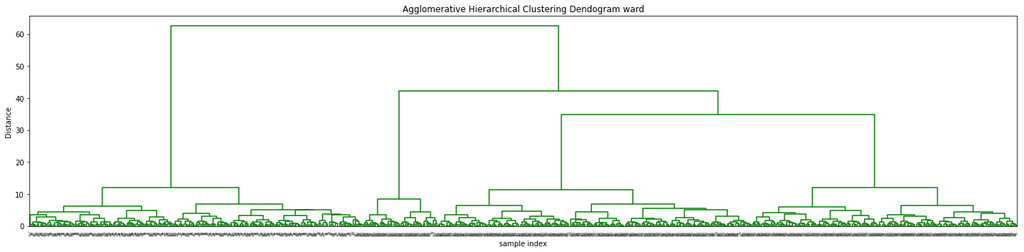

```python
## plot Agglomerative Hierarchical Clustering Dendogram ward
plt.figure(figsize=(20, 5))
plt.title('Agglomerative Hierarchical Clustering Dendogram ward')
plt.xlabel('sample index')
plt.ylabel('Distance')
dendrogram(z6, leaf_rotation=45.,color_threshold = 600, leaf_font_size=4. )
plt.tight_layout()
```

```python
#Get the silhoutte score of the hierarchical clustering, it always used to be beween -1 to 1 for better clustering it would be 1 and - means bad clustering
#The best value is 1 and the worst value is -1. Values near 0 indicate overlapping clusters.
#Negative values generally indicate that a sample has been assigned to the wrong cluster, as a different cluster is more similar.
preds_h = model_average.fit_predict(credit_costumer_z_hc_ward_4)
S8 = silhouette_score(credit_costumer_z_hc_ward_4,preds_h)
S8
```

```
0.5072606893295124
```

```python
ca = 0
cb = 0
```

```python
round(S1a,2)
round(S2a,2)
```

```
0.38
```

```python
data = {
        'Name of Model':  ['K-means_clust3','K-means_clust4','HC_Avg_Lnkg_clust3','HC_Cmplt_Lnkg_clust3',
                           'HC_ward_Lnkg_clust3','HC_Avg_Lnkg_clust4','HC_Cmplt_Lnkg_clust4','HC_ward_Lnkg_clust4'],
        'Cophenet_coeef': [ca,cb,c1, c2, c3, c4 ,c5, c6],
        'Silhouette Score':[S1a, S2a, S3, S4, S5, S6, S7, S8]
        }

metricsdata = pd.DataFrame (data, columns = ['Name of Model','Cophenet_coeef', 'Silhouette Score'])
pd.reset_option("display.max_columns",None)
metricsdata
```

|  | Name of Model | Cophenet_coeef | Silhouette Score |
| --- | --- | --- | --- |
| 0 | K-means_clust3 | 0.000000 | 0.493001 |
| 1 | K-means_clust4 | 0.000000 | 0.384907 |
| 2 | HC_Avg_Lnkg_clust3 | 0.906738 | 0.562996 |
| 3 | HC_Cmplt_Lnkg_clust3 | 0.885953 | 0.564994 |
| 4 | HC_ward_Lnkg_clust3 | 0.777403 | 0.517561 |
| 5 | HC_Avg_Lnkg_clust4 | 0.868892 | 0.460472 |
| 6 | HC_Cmplt_Lnkg_clust4 | 0.898086 | 0.399772 |
| 7 | HC_ward_Lnkg_clust4 | 0.792566 | 0.507261 |

Conclusion:

1. As per the elbow method number of clusters to be opted for K means is 3 and slight deviation is there at four as well. so k means and hierarchical cluster algorithms, both are formed with 3 and 4 clusters and tested for the given problem.
2. Observed that k- means algorithm with 3 clusters has given silhoutte score as .49 where in for 4 number of clusters the silhoutte score as .38
3. silhoutte score is always beween -1 to 1 for better clustering it would be 1 and - means bad clustering the best value is 1 and the worst value is -1. Values near 0 indicate overlapping clusters. Negative values generally indicate that a sample has been assigned to the wrong cluster, as a different cluster is more similar. Here, silhoutte score is .49 for k-means clustering algorithm with 3 number of clusters than with the 4 clusters.
4. Similarly silhoutte score and cophenetic score is computed for the hierarchical clustering with 3 and 4 cluster with the distance computation using Euclidean method and Average, complete and ward linkage methods.
5. Amongst all the three linkage methods 'complete' linkage with the three clusters has given the best silhoutte score as .56 which is closer to 1 but cophentic score is not so good as in average linkage method with 3 number of clusters.
6. As a conclusion hierarchical clustering with 'Average linkage' with the three clusters has given better results on cophenetic score and a ery meager is present in the silhoutte score. cophenet index is a measure of the correlation between the distance of points in feature space and distance on dendrogram closer it is to 1, the better is the clustering. so hierarchical clustering with average linkage with the three clusters is the best unsupervised algorithm for the given problem. ( The reasons being very good cophenetic score and at par level of silhoutte )

```python
preds_h_cmplt = model_average.fit_predict(credit_costumer_z_hc_cmplt_3)
```

```
array([[<matplotlib.axes._subplots.AxesSubplot object at 0x7fae47545d30>,
      dtype=object)
```

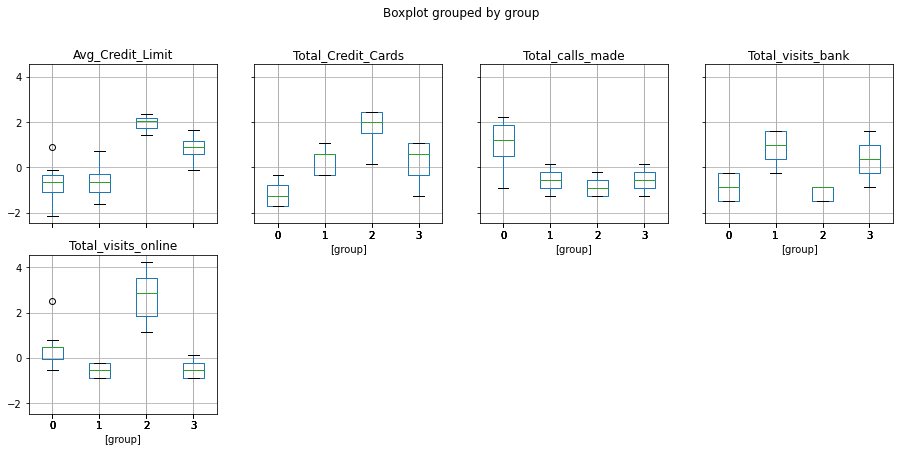

```python
credit_costumer_z_hc_cmplt_3["group"] = preds_h_cmplt
credit_costumer_z_hc_cmplt_3.boxplot(by = 'group',  layout=(3,4), figsize=(15, 10))
```

```python
credit_costumer_z_hc_avg_3 = credit_costumer_z_hc_avg_3.drop(['labels'],axis=1)
```

```
array([[<matplotlib.axes._subplots.AxesSubplot object at 0x7fae48870080>,
      dtype=object)
```

[figure not shown]

```python
credit_costumer_z_hc_avg_3["group"] = preds_h
credit_costumer_z_hc_avg_3.boxplot(by = 'group',  layout=(3,4), figsize=(15, 10))
```

```
array([[<matplotlib.axes._subplots.AxesSubplot object at 0x7fae4a5e7e10>,
      dtype=object)
```

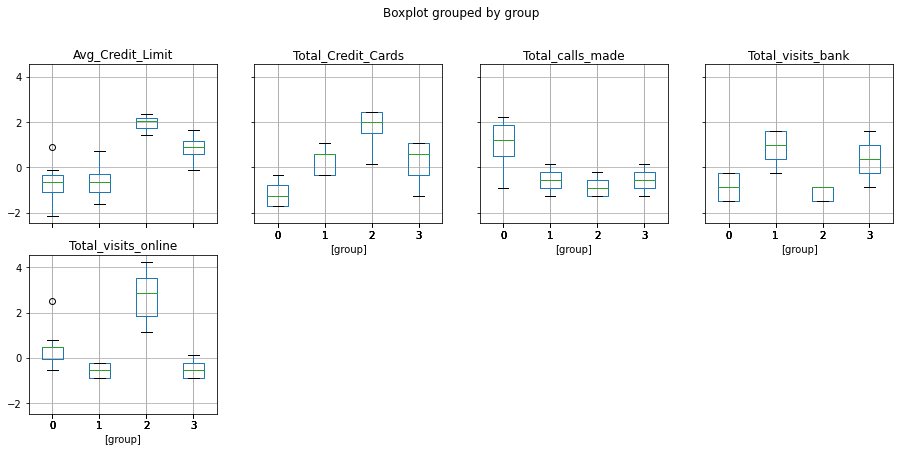

```python
# Get the box plot for the different groups of customer behaviours on all the attributes for better personalised targeting or promotions
credit_costumer_z_hc_avg_4["group"] = preds_h
credit_costumer_z_hc_avg_4.boxplot(by = 'group',  layout=(3,4), figsize=(15, 10))
```

**Group 0:** They are the customers with the below minimum credit limit, not holding credit cards but they attempt to call a bank more frequently but rarely visits the bank in person or in online.

**Group 1:** They are the customers with the below minimum credit limit, holding minimum number of credit cards but they attempt to call a bank rarely but prefer to do transction in person than in online.

**Group 2:** They are the customers with the high credit limit, holding many number of credit cards. They do not attempt to call a bank and rarely visits the bank in person but they perfered to do transaction in online most of the time.

**Group 3:** They are the customers with the high credit limit, holding many number of credit cards. They do not attempt to call a bank and they perfered to do transaction by in person but they are not perfered to do transaction in online.

**1.How many different segments of customers are there?**

**There are three groups of customers. But 4 groups of customers could also be a possibility. But the results have been concluded for both the different set of groups**

**2. How are these segments different from each other?**

**As per K-means:**

Group 2(Premium): They are the customers with the high credit limit, holding many number of credit cards. They do not attempt to call a bank and rarely visits the bank in person but they perfered to do transaction in online most of the time.

**As per Hierarchial Clustering:**

Group 0: They are the customers with the below average credit limit, holding minimum number of credit cards but they attempt to call the bank very frequently and prefer to do transaction online.

Group 1 (Premium): They are the customers with the very good minimum credit limit and have many credit cards. They prefer to do transactions online.

Group 2:: They are the customers with the average credit limit and do not hold many number of credit cards. They prefer to bank transactions in person.

What are your recommendations to the bank on how to better market to and service these customers?

**Since Hierarchial clustering is better the suggestions have been made for HC average linkage which seemed to show better results. ( As per Cophenetic and Silhouette Score**

**Recommendation for 3 Groups:**

For Group 0 : These are the customers who have low credit limit. For this group the bank should provide financial education to help the customer improve their credibility and manage finances. This will help the group gain a better credit score which in turn increases their credit-limit with the bank. This group of customers can be targeted for getting more credit cards and hence improve bank business. Since they frequently call the bank there is a high possibilty they are in need of credit cards.

For Group 1: For the customers in this group the bank should try and improve their online banking experience and ensure they have a smooth experience through better User Interface services eg: More interactive and user friendly experience, better online security etc.

For Group 2 : These are the customers who prefer to come to the bank for their banking transactions. For this group the bank should try to improve in-house facilities and provide better hospitality. The bank should also encourage these customers to try the online banking services.

**Recommendation for 4 Groups:**

For group 2 ( Premium Customer ) : For the customers in this group the bank should try and improve their online banking experience and ensure they have a smooth experience through better User Interface services eg: More interactive and user friendly experience, better online security etc.

For group 3 ( Premium Customer) : These are the customers who prefer to come to the bank for their banking transactions. For this group the bank should try to improve in-house facilities and provide better hospitality. The bank should also encourage these customers to try the online banking services.

For group 0 ( Non- Premium Customer ): These are the customers who have low credit limit. For this group the bank should provide financial education to help the customer improve their credibility and manage finances.